# My visual data story

## How many responses of the survey was done by people above 18?

I wish to know how many responses of the survey was done by people above 18 and how many was not. Because I think it can shows how YouTube advertisement strategy is when it faces different groups. Divide the response into different age groups can help us to find the trend of it.

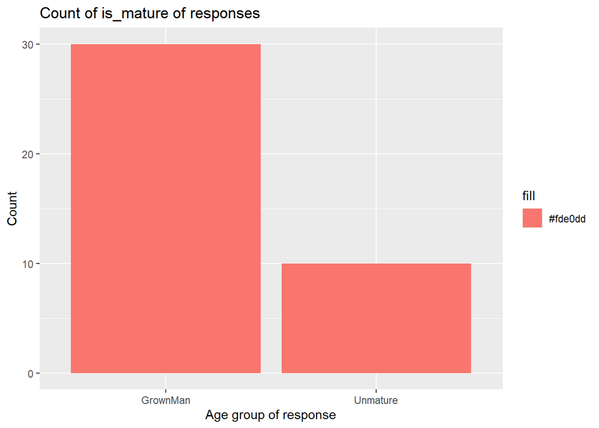

And from the result we can know that the major age group of the responses are from adults, I assume maybe because kids are less interested in doing surveys.

## The relationship of response submit time and the numebr of ads user watched

I want to find the trend of ads number and the response time.

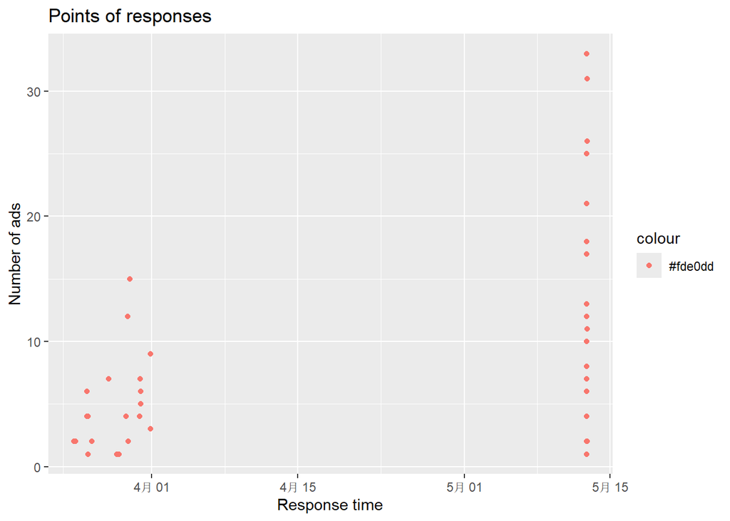

From the chart, no clear pattern was found but there are some extreme points like the 2 points in May 15, they are both over 30, we can analyze the two points to find out the reason.

## The relationship between age and trust level to ads

In common sense, elder people are more likely to know less of the internet so they possibly would have higher trust to ads, I want to investigate on that and see if the rumour is true or false.

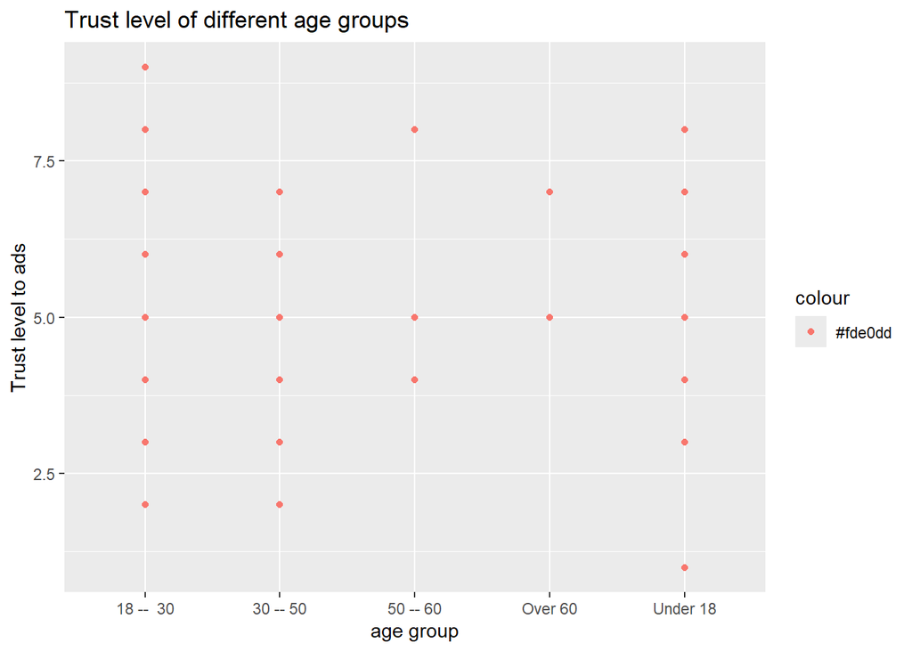

From the plot, we can see the trust level is evenly distributed in the age groups of Under 18 to 30-50. The age group of 50-60 and over 60, we usually identified as the elder people, it does seems they have a higher average trust level to ads compare to others, but a conclusion can’t be made since there are not sufficient data.